# Определение параметров насоса

Имеются два атмосферных бака: А и Б. Из бака А необходимо периодически перекачивать воду в бак Б.

[figure not shown]

Перекачка начинается при достижении в баке А уровня воды $z_A^{max}$ и заканчивается при уровне $z_A^{min}$. Входной штуцер бака Б находится на высоте $z_Б^{max}$, $z_A$, $z_Б$ - отметки (например, относительно уровня моря) дна бака А и Б соответственно, м.

Примем:

```python
z_А = 25  # отметка дна бака А относительно уровня моря, м
z_Б = 27  # отметка дна бака Б относительно уровня моря, м
z_А_max = 10 # уровень воды в баке А при котором начинается откачка, м
z_А_min = 1  # уровень воды в баке А при котором заканчивается откачка, м
z_Б_max = 17  # отметка входного штуцера бака Б, м
```

Производительность насоса $Q$ выбирается исходя из времени, за которое необходимо откачать воду из бака А в бак Б. Примем:

```python
Q = 50  # производительность насоса, м3/ч
```

Баки соединяются трубопроводом. Внутренний диаметр трубопровода выбирается таким образом, чтобы скорость потока внутри трубопровода находилась в диапазоне [1,5; 3,0] м/с. Чем больше диаметр трубопровода (меньше скорость потока) тем выше капитальные затраты, но тем ниже потери давления в трубопроводе, а значит, меньше потребление электроэнергии электродвигателем насоса.

Т.к. откачка воды будет производиться периодически, то пойдём по пути снижения капитальных затрат и из рекомендуемого диапазона скоростей возьмём верхнее значение.

```python
from math import pi, sqrt
w = 3  # целевое значение скорости потока, м/с
F = Q / 3600 / w  # целевое значение площади внутреннего сечения трубы
d = sqrt(4 * F / pi)  # внутренний диаметр трубы (м) при котором скорость потока составит w при объёмном расходе Q
d
```

```
0.07677647766029677
```

Толщина стенки трубы выбирается исходя из соображений сохранения прочности в течение всего срока эксплуатации трубопровода в заданных условиях.  
Диаметры труб и толщины стенок не могут быть произвольными, а выбираются из номенклатурного ряда, предлагаемого производителями труб. В нашем случае выберем трубу 89х3,5.

```python
D = 89; h = 3.5  # внешний диаметр трубопровода и толщина стенки, мм
d = (D - 2 * h) * 1e-3  # внутренний диаметр, м
d
```

```
0.082
```

Примем, что трубопровод, соединяющий бак А и Б состоит из следующих элементов: 150 м трубы, 16 отводов 90 градусов, 4 отвода 45 градусов, два запорных вентиля перед и за насосом.

```python
L = 150  # обшая длина труб, м
n_elb90 = 16  # количесто отводов 90 градусов
n_elb45 = 4  # количесто отводов 45 градусов
n_sv = 2  # количесто отводов запорных вентелей
```

Для выбора параметров насоса необходимо определить граничные условия, при которых насос будет эксплуатироваться в течение всего срока его службы. Зададимся следующими величинами:

```python
Delta_new = 0.1e-3  # шероховатость внутренних стенок новых труб, м
Delta_old = 0.3e-3  # шероховатость внутренних стенок старых труб, м
dz_max = (z_Б + z_Б_max) - (z_А + z_А_min)  # максимальная высота подъёма воды (бак А пустой)
dz_min = (z_Б + z_Б_max) - (z_А + z_А_max)  # минимальная высота подъёма воды (бак А полный)
dz_max, dz_min
```

```
(18, 9)
```

Для нахождения потерь давления в трубопроводе воспользуемся модулем `hydrcalc` [1].

```python
import sys
sys.path.append("../0026_Гидр_расч_трубопровода")
from hydrcalc import ppln_get_defs, ppln_calc_dH
```

```python
def get_elems():
    #Формируем список элементов трубопровода
    enter = {'type': 'lrc', 'value': 0.5}  #вход в трубопровод из бака
    pipe = {'type': 'pipe', 'qty': L}  # труба суммарной длиной L
    elbow90 = {'type': 'elbow', 'qty': n_elb90}  # отвод 90 градусов
    elbow45 = {'type': 'elbow', 'deg': 45, 'qty': n_elb45}  # отвод 45 градусов
    stop_valve = {'type': 'Kv', 'value': 120, 'qty': n_sv}  # запорный вентиль, Kv = 120 м3/ч
    exit = {'type': 'lrc', 'value': 1} #выход из трубопровода
    elems =[enter, pipe, elbow90, elbow45, stop_valve, exit]
    return elems
```

```python
defs = ppln_get_defs(d)
defs
```

```
{'D': 0.082, 'Delta': 0.0002, 'kvisc': 1e-06, 'deg': 90, 'RD': 1.5, 'qty': 1}
```

```python
elems = get_elems()
defs['Delta'] = 0.1e-3  # шероховатость 0,1 мм - новые трубы
dHs_new = ppln_calc_dH(Q, elems, **defs)
dHs_new  # потери давления в каждом элементе нового трубопровода
```

```
[0.1763271418625483,
 14.043254095479462,
 2.240215934995174,
 0.3287970080898642,
 3.5406812950622597,
 0.3526542837250966]
```

```python
dH_new = sum(dHs_new)
dH_new # суммарные потери давления в новом трубопроводе
```

```
20.681929759214405
```

```python
elems = get_elems()
defs['Delta'] = 0.3e-3  # шероховатость 0,3 мм - старые трубы
dHs_old = ppln_calc_dH(Q, elems, **defs)
dHs_old  # потери давления в каждом элементе старого трубопровода
```

```
[0.1763271418625483,
 18.215840943834177,
 2.326208142316697,
 0.3395460340050545,
 3.5406812950622597,
 0.3526542837250966]
```

```python
dH_old = sum(dHs_old)
dH_old  # суммарные потери давления в старом трубопроводе
```

```
24.951257840805834
```

Теперь построим характеристики трубопровода (гидравлической сети) для различных условий работы. Для нахождения характеристики трубопровода используем класс `Pipeline` (см. [2])

```python
from pipeline import Pipeline
```

```python
ppln_new = Pipeline(Q, dH_new)  # характеристика нового трубопровода
ppln_old = Pipeline(Q, dH_old)  # характеристика старого трубопровода
```

Самый благоприятный режим работы насоса (максимальная производительность): новые трубы, бак А полон.  
Самый неблагоприятный режим работы насоса (минимальная производительность): старые трубы, бак А пустой.

```python
# точки для построения левой границы (самый неблагоприятный режим работы насоса)
Qs_l, Hs_l = ppln_old.get_curve(0, 70, dz_max)
# точки для построения правой границы (самый благоприятный режим работы насоса)
Qs_r, Hs_r = ppln_new.get_curve(0, 70, dz_min)
```

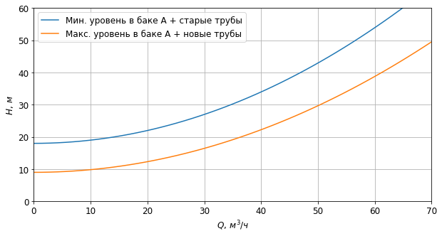

```python
import matplotlib.pyplot as plt
plt.rcParams['font.size'] = 12.0
fig, ax = plt.subplots(figsize = (10,5))
ax.grid(); ax.set_xlim(0,70); ax.set_ylim(0,60)
ax.plot(Qs_l, Hs_l, label = "Мин. уровень в баке А + старые трубы")
ax.plot(Qs_r, Hs_r, label = "Макс. уровень в баке А + новые трубы")
ax.set_xlabel('$Q,\, м^3/ч$'); ax.set_ylabel('$H,\, м$')
ax.legend();
```

Рабочая точка насоса в середине срока его службы должна находиться посредине между границами. Значение подачи насоса нам известно: 50 $м^3/ч$, необходимо определиться с его напором, найдя значения $H$ для обеих кривых при $Q = 50\, м^3/ч$ и расчитав среднее значение.

```python
H_l = ppln_old.dH_Q(Q, dz_max)  # напор при Q = 50 для левой границы
H_r = ppln_new.dH_Q(Q, dz_min)  # напор при Q = 50 для правой границы
H_m = (H_r + H_l) / 2
H_m  # напор насоса в середине срока его службы при среднем уровне воды в баке А
```

```
36.316593800010125
```

С течением времени рабочая (напорная) характеристика насоса деградирует. Если новый насос при подаче $Q$ развивает напор $H$, то насос в конце срока своей службы при подаче $Q$ развивает напор $deg \cdot H$, где $deg$ - степень деградации рабочей характеристики насоса. Для нашего случая примем, что степень деградации рабочей характеристики насоса к концу срока его службы составляет 0,9. Значит в середине срока службы насоса степень деградации составит 0,95. Таким образом, напор нового насоса должен быть равен:

```python
H = H_m / 0.95
H
```

```
38.22799347369487
```

Для надёжности за границы допустимого рабочего диапазона насоса примем линии, полученные из характеристик сети для рассмотренных крайних случаев, смещённые по оси производительности на 10% влево и вправо соответственно.

```python
import numpy as np
Qs_l = np.array(Qs_l) * 0.9
Qs_r = np.array(Qs_r) * 1.1
```

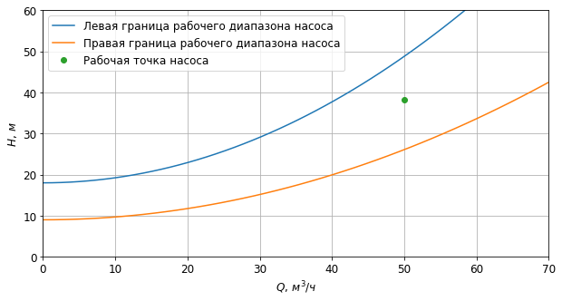

```python
fig, ax = plt.subplots(figsize = (10,5))
ax.grid(); ax.set_xlim(0,70); ax.set_ylim(0,60)
ax.plot(Qs_l, Hs_l, label = "Левая граница рабочего диапазона насоса")
ax.plot(Qs_r, Hs_r, label = "Правая граница рабочего диапазона насоса")
ax.plot(Q, H, 'o', label = "Рабочая точка насоса")
ax.set_xlabel('$Q,\, м^3/ч$'); ax.set_ylabel('$H,\, м$')
ax.legend();
```

## Выводы

Рабочая характеристика насоса должна проходить через точку $Q = 50\,м^3/ч$, $H = 38\,м$ и рабочий диапазон характеристики должен пересекать обе границы. В этом случае рабочая точка насоса будет находиться внутри рабочего диапазона в течение всего срока службы насоса при любом уровне воды в баке А и средняя скорость перекачки жидкости составит около 50 $м^3/ч$. Если рабочая характеристика пройдёт выше заданной рабочей точки, то средняя скорость перекачки воды в течение всего срока службы насоса будет больше 50 $м^3/ч$, если ниже - то меньше 50 $м^3/ч$.

Следует заметить, что если рабочий диапазон насоса не доходит до правой границы, то при новых трубах и максимальном уровне в баке А электродвигатель насоса будет потреблять электрическую мощность больше допустимого значения, что приведёт к его перегреву.

Так же не стоит забывать о проверке располагаемого кавитационного запаса системы [3].

### Ссылки

1. Гидравлический расчёт трубопровода
2. Моделирование характеристики гидравлической сети
3. Расчёт кавитационного запаса насоса

[Инженерные расчёты на Python](https://zen.yandex.ru/id/5f33dcd5554adc5b33aaee83), С.В. Медведев, 2020  
Использование Python и Jupyter Notebook для инженерных расчётов, С.В. Медведев, 2020